# Analyzing Individual BGG Users

Phil Henrickson

2021-12-06

Load previously queried training and test data from the local layer.

Set function for displaying probabilities

Fit models and analyze collection for **Ogzz**.

## Games in Collection

How many games has the user owned/played in the training set (games prior to 2020)?

```
## # A tibble: 1 × 3
##   username games_owned games_played
##   <chr>          <dbl>        <dbl>
## 1 Ogzz              30          109
```

## Coefficients for Ogzz

Examine coefficients from the trained model.

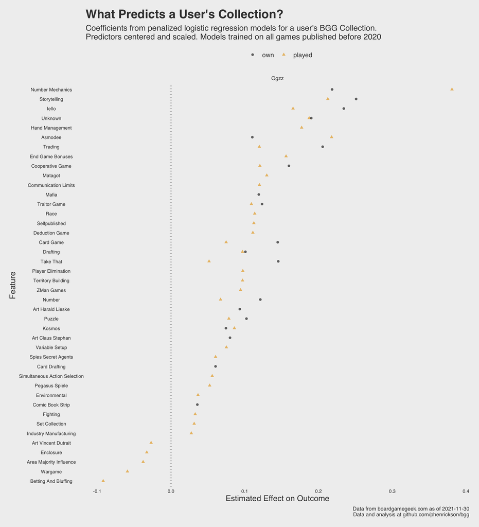

## Visualizing Predictors for Ogzz’s Collection

Examine density of most important features for predicting whether user owns a game.

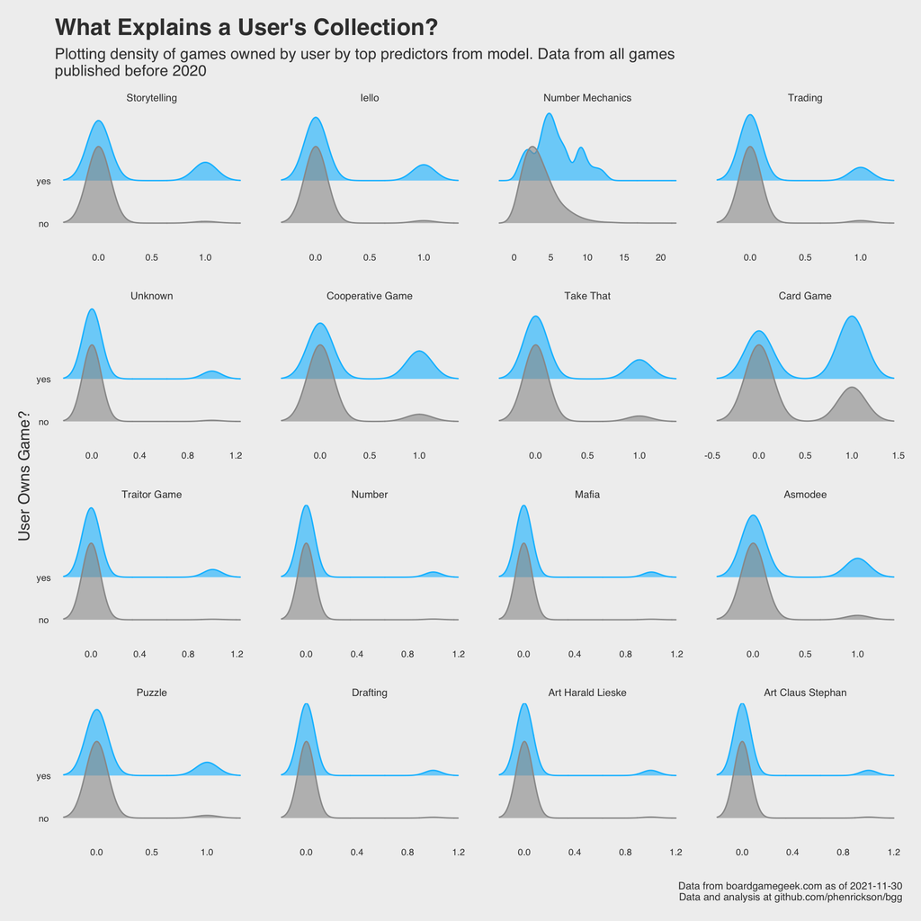

## Assessment

Examine separation plot for training set (cross validated predictions).

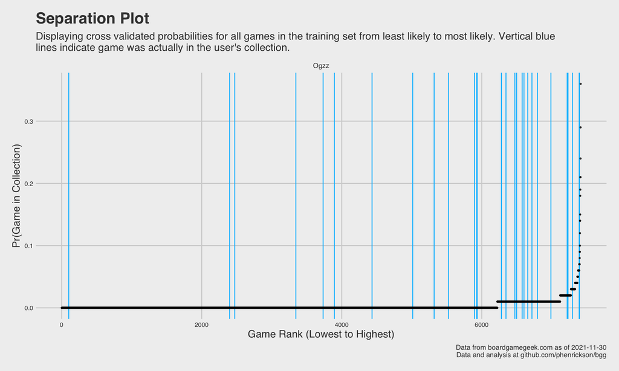

Formally assess how well the model did in resampling.

| outcome_type | .metric | .estimator | .estimate |
| --- | --- | --- | --- |
| own | roc_auc | binary | 0.788 |
| played | roc_auc | binary | 0.856 |

## Predicted Games in Collection from Training

Examine top games from resampling.

Top Overall Games for User from Resampling

| username | yearpublished | game_id | name | pred_played | pred_own | actual_played | actual_own |
| --- | --- | --- | --- | --- | --- | --- | --- |
| Ogzz | 2019 | 245655 | The King's Dilemma | 0.40 | 0.36 | 0 | 0 |
| Ogzz | 2014 | 156129 | Deception: Murder in Hong Kong | 0.79 | 0.29 | 1 | 0 |
| Ogzz | 2016 | 193037 | Dead of Winter: The Long Night | 0.47 | 0.24 | 1 | 0 |
| Ogzz | 2018 | 225167 | Human Punishment: Social Deduction 2.0 | 0.08 | 0.21 | 0 | 0 |
| Ogzz | 2017 | 228660 | Betrayal at Baldur's Gate | 0.23 | 0.21 | 0 | 0 |
| Ogzz | 2012 | 105551 | Archipelago | 0.40 | 0.19 | 0 | 0 |
| Ogzz | 2014 | 156091 | Sons of Anarchy: Men of Mayhem | 0.10 | 0.18 | 0 | 0 |
| Ogzz | 2017 | 174430 | Gloomhaven | 0.90 | 0.15 | 1 | 0 |
| Ogzz | 2017 | 224037 | Codenames: Duet | 0.40 | 0.14 | 0 | 0 |
| Ogzz | 2019 | 276498 | Paris: La Cité de la Lumière | 0.06 | 0.14 | 0 | 0 |
| Ogzz | 2014 | 164265 | Witness | 0.16 | 0.12 | 0 | 0 |
| Ogzz | 2015 | 172242 | Exploding Kittens: NSFW Deck | 0.31 | 0.10 | 0 | 0 |
| Ogzz | 2018 | 225694 | Decrypto | 0.08 | 0.09 | 1 | 0 |
| Ogzz | 2017 | 195539 | The Godfather: Corleone's Empire | 0.11 | 0.09 | 0 | 0 |
| Ogzz | 2011 | 96613 | Alcatraz: The Scapegoat | 0.03 | 0.08 | 0 | 0 |
| Ogzz | 2016 | 204305 | Sherlock Holmes Consulting Detective: Jack the Ripper & West End Adventures | 0.08 | 0.07 | 0 | 0 |
| Ogzz | 2004 | 10547 | Betrayal at House on the Hill | 0.26 | 0.07 | 1 | 1 |
| Ogzz | 2017 | 230430 | Unlock!: Escape Adventures – Temple of Ra | 0.17 | 0.07 | 0 | 0 |
| Ogzz | 2016 | 231748 | Time Bomb Evolution | 0.05 | 0.07 | 0 | 0 |
| Ogzz | 2018 | 240196 | Betrayal Legacy | 0.37 | 0.07 | 1 | 1 |
| Ogzz | 2018 | 205896 | Rising Sun | 0.83 | 0.07 | 0 | 0 |
| Ogzz | 1999 | 50 | Lost Cities | 0.02 | 0.06 | 0 | 0 |
| Ogzz | 2012 | 127398 | Legends of Andor | 0.09 | 0.06 | 0 | 0 |
| Ogzz | 2017 | 215842 | Exit: The Game – The Polar Station | 0.09 | 0.06 | 0 | 0 |
| Ogzz | 2009 | 40832 | Keltis: Das Kartenspiel | 0.02 | 0.06 | 0 | 0 |
| Ogzz | 1982 | 2511 | Sherlock Holmes Consulting Detective: The Thames Murders & Other Cases | 0.07 | 0.06 | 1 | 0 |
| Ogzz | 2005 | 16933 | Super Munchkin | 0.20 | 0.06 | 0 | 0 |
| Ogzz | 2019 | 279613 | Unlock!: Timeless Adventures | 0.14 | 0.06 | 0 | 0 |
| Ogzz | 2017 | 216092 | Unlock!: Escape Adventures – Squeek & Sausage | 0.02 | 0.06 | 1 | 0 |
| Ogzz | 2017 | 224316 | Unlock!: Escape Adventures – The Elite | 0.04 | 0.06 | 0 | 0 |

[output cut: 70 more lines]

### Most and Least Likely Games

What game does the model think Ogzz is **most likely to own** that is **not** in their collection?

| username | yearpublished | game_id | name | pred_own |
| --- | --- | --- | --- | --- |
| Ogzz | 2019 | 245655 | The King's Dilemma | 0.36 |

What game does the model think Ogzz is **least likely to own** that **is** in their collection?

| username | yearpublished | game_id | name | pred_own |
| --- | --- | --- | --- | --- |
| Ogzz | 2005 | 12333 | Twilight Struggle | 0 |

### Top Games by Year

Top 25 games most likely to be owned by the user in each year, highlighting in blue the games that the user has owned/played.

| rank | 2012 | 2013 | 2014 | 2015 | 2016 | 2017 | 2018 | 2019 |
| --- | --- | --- | --- | --- | --- | --- | --- | --- |
| 1 | Archipelago | Rory's Story Cubes: Prehistoria | Deception: Murder in Hong Kong | Exploding Kittens: NSFW Deck | Dead of Winter: The Long Night | Betrayal at Baldur's Gate | Human Punishment: Social Deduction 2.0 | The King's Dilemma |
| 2 | Legends of Andor | Kobayakawa | Sons of Anarchy: Men of Mayhem | T.I.M.E Stories | Sherlock Holmes Consulting Detective: Jack the Ripper & West End Adventures | Gloomhaven | Decrypto | Paris: La Cité de la Lumière |
| 3 | The Manhattan Project | Funemployed | Witness | Mafia de Cuba | Time Bomb Evolution | Codenames: Duet | Betrayal Legacy | Unlock!: Timeless Adventures |
| 4 | Agents of SMERSH | Smash Up: Awesome Level 9000 | Dead of Winter: A Crossroads Game | March of the Ants | Exit: The Game – The Secret Lab | The Godfather: Corleone's Empire | Rising Sun | Unlock!: Exotic Adventures – Expedition: Challenger |
| 5 | Targi | Smash Up: The Obligatory Cthulhu Set | Imperial Settlers | RYŪ | Inis | Unlock!: Escape Adventures – Temple of Ra | Unlock!: Secret Adventures – A Noside Story | Decktective: Bloody-Red Roses |
| 6 | Neuroshima: Convoy | Hanamikoji | Sheriff of Nottingham | The Game | Exit: The Game – The Pharaoh's Tomb | Exit: The Game – The Polar Station | Unlock!: Secret Adventures – The Adventurers of Oz | Exit: The Game – Theft on the Mississippi |
| 7 | Mice and Mystics | The Quiet Year | Ca$h 'n Guns (Second Edition) | Argonauts | Tales & Games: The Pied Piper | Unlock!: Escape Adventures – Squeek & Sausage | Unlock!: Heroic Adventures | Adventure Games: The Dungeon |
| 8 | Serenissima (Second Edition) | Infamy | Shadows of Malice | Potion Explosion | Smash Up: It's Your Fault! | Unlock!: Escape Adventures – The Elite | Detective: A Modern Crime Board Game | Call to Adventure |
| 9 | Seasons | Firefly: The Game | Stay Away! | Aye, Dark Overlord! The Green Box | Pandemic: Reign of Cthulhu | Unlock!: Escape Adventures – Doo-Arann Dungeon | Big Trouble in Little China: The Game | HEXplore It: The Forests of Adrimon |
| 10 | Waka Waka | The Doom That Came to Atlantic City | Artificium | Fairytale Gloom | Behind the Throne | Fast Forward: FEAR | Who Goes There? | 50 Clues: The Pendulum of the Dead |
| 11 | Winter Tales | Patchistory | King of New York | Chaosmos | Codenames: Pictures | Unlock!: Escape Adventures – Fifth Avenue | Château Aventure | 50 Clues: The Fate of Leopold |
| 12 | Dixit: Journey | Serpent's Tongue | Fallen | Fireteam Zero | When I Dream | This War of Mine: The Board Game | Catan Histories: Rise of the Inkas | Carnival of Monsters |
| 13 | Space Cadets | Ultimate Werewolf: Inquisition | Smash Up: Science Fiction Double Feature | Kingdom Death: Monster | Mansions of Madness: Second Edition | Exit: The Game – The Forbidden Castle | The City of Kings | Spire's End |
| 14 | Coup | Rory's Story Cubes: Enchanted | Smash Up: Monster Smash | Karuba | Capital Lux | Escape the Dark Castle | Holding On: The Troubled Life of Billy Kerr | Choose Your Own Adventure: War with the Evil Power Master |
| 15 | The Resistance: Avalon | Room 25 | Ultimate Werewolf: Deluxe Edition | 504 | Warhammer Quest: Silver Tower | Break the Code | Fairy Tile | The Isle of Cats |
| 16 | Uchronia | Bomb Squad | Spyfall | Feelinks | Agricola (Revised Edition) | Smash Up: What Were We Thinking? | Vengeance | Middara: Unintentional Malum – Act 1 |
| 17 | Urbion | Agent Hunter | Ultimate Werewolf | Salem 1692 | The Mysterious Forest | Pulsar 2849 | The Mind | Aquatica |
| 18 | Tzolk'in: The Mayan Calendar | One Zero One | Co-Mix | The Big Book of Madness | Assembly | Fallout | Trapwords | Comanauts |
| 19 | Spartacus: A Game of Blood and Treachery | Pathfinder Adventure Card Game: Rise of the Runelords – Base Set | Greed | Exploding Kittens | Escape the Room: Mystery at the Stargazer's Manor | Near and Far | Unlock!: Secret Adventures – Tombstone Express | The 7th Continent: Classic Edition |
| 20 | Star Trek: Catan | City of Remnants | Heroes of Normandie | FUSE | StoryLine: Fairy Tales | Twilight Imperium: Fourth Edition | Warhammer Quest: Blackstone Fortress | Watergate |
| 21 | Goblins, Inc. | Titanium Wars | Jäger und Späher | ...and then, we held hands. | Timebomb | Lobotomy | Narcos: The Board Game | Freshwater Fly |
| 22 | OddVille | The Witches: A Discworld Game | The Battle of Five Armies | Smash Up: Pretty Pretty Smash Up | Fuji Flush | Fog of Love | Choose Your Own Adventure: House of Danger | Imperial Settlers: Empires of the North |
| 23 | Fantastiqa: The Rucksack Edition | Amerigo | Patchwork | Die Legenden von Andor: Chada & Thorn | Codenames: Deep Undercover | Fantasy Defense | Newton | Abomination: The Heir of Frankenstein |
| 24 | Doctor Who: The Card Game | Rockwell | Pack of Heroes | Castellion | Dead Last | First Martians: Adventures on the Red Planet | Caper | Gardens of Babylon |
| 25 | Der Hobbit: Eine unerwartete Reise – Das Spiel zum Film | Theseus: The Dark Orbit | Star Realms | Sylvion | Loot N Run | Legends of Andor: The Last Hope | Speakeasy Blues | Tussie Mussie |

### Interactive Table

Interactive table for predictions from resampling.

|  | username | yearpublished | rank | game_id | name | pred_played | pred_own | actual_played | actual_own |
| --- | --- | --- | --- | --- | --- | --- | --- | --- | --- |
| 1 | Ogzz | 1900 | 39 | 7316 | Bingo | 0.05 | 0.05 | 0 | 0 |
| 2 | Ogzz | 1900 | 42 | 15549 | Roulette | 0.01 | 0.05 | 0 | 0 |
| 3 | Ogzz | 1900 | 151 | 2083 | Checkers | 0.01 | 0.02 | 0 | 0 |
| 4 | Ogzz | 1900 | 239 | 15878 | Rummy | 0.03 | 0.02 | 0 | 0 |
| 5 | Ogzz | 1900 | 254 | 9364 | Doppelkopf | 0.01 | 0.02 | 0 | 0 |
| 6 | Ogzz | 1900 | 259 | 2785 | Game of Goose | 0.16 | 0.02 | 0 | 0 |
| 7 | Ogzz | 1900 | 263 | 11670 | The Game of Authors | 0.1 | 0.02 | 0 | 0 |
| 8 | Ogzz | 1900 | 296 | 11901 | Tic-Tac-Toe | 0.01 | 0.01 | 0 | 0 |
| 9 | Ogzz | 1900 | 300 | 171 | Chess | 0.01 | 0.01 | 0 | 0 |
| 10 | Ogzz | 1900 | 302 | 2065 | Shogi | 0.02 | 0.01 | 0 | 0 |

[output cut: 7403 more lines]

## Predicted Games in Collection 2020 and On

Examine the top games for the test set.

Top Predicted Games for User, 2020 and On

| username | yearpublished | game_id | name | rank | own | played |
| --- | --- | --- | --- | --- | --- | --- |
| Ogzz | 2020 | 293531 | Detective: A Modern Crime Board Game – Season One | 1 | 0.06 | 0.12 |
| Ogzz | 2020 | 302809 | Betrayal at Mystery Mansion | 2 | 0.06 | 0.13 |
| Ogzz | 2020 | 302425 | Unlock!: Mythic Adventures | 3 | 0.06 | 0.13 |
| Ogzz | 2020 | 271524 | TIME Stories Revolution: A Midsummer Night | 4 | 0.05 | 0.11 |
| Ogzz | 2020 | 312267 | Star Wars: Unlock! | 5 | 0.05 | 0.10 |
| Ogzz | 2020 | 327913 | Unlock!: Timeless Adventures – Arsène Lupin und der große weiße Diamant | 6 | 0.05 | 0.10 |
| Ogzz | 2020 | 332229 | Unlock!: Heroic Adventures – Hinunter in den Kaninchenbau | 7 | 0.05 | 0.10 |
| Ogzz | 2020 | 332230 | Unlock!: Heroic Adventures – Insert Coin | 8 | 0.05 | 0.10 |
| Ogzz | 2020 | 341008 | Unlock!: Heroic Adventures – Sherlock Holmes: Der scharlachrote Faden | 9 | 0.05 | 0.10 |
| Ogzz | 2020 | 270685 | Capone: The Business of Prohibition | 10 | 0.04 | 0.01 |
| Ogzz | 2020 | 315954 | Hunt A Killer: Death at the Dive Bar | 11 | 0.04 | 0.11 |
| Ogzz | 2020 | 313817 | Hello Neighbor: The Secret Neighbor Party Game | 12 | 0.04 | 0.08 |
| Ogzz | 2020 | 298701 | Decktective: The Gaze of the Ghost | 13 | 0.04 | 0.12 |
| Ogzz | 2020 | 307191 | Four against the Great Old Ones | 14 | 0.03 | 0.07 |
| Ogzz | 2020 | 280748 | Escape the Dark Sector | 15 | 0.03 | 0.05 |
| Ogzz | 2020 | 311686 | Escape the Room: The Cursed Dollhouse | 16 | 0.03 | 0.05 |
| Ogzz | 2020 | 301767 | Mysterium Park | 17 | 0.03 | 0.34 |
| Ogzz | 2020 | 294235 | Crime Zoom: His Last Card | 18 | 0.03 | 0.11 |
| Ogzz | 2020 | 295488 | Andor: The Family Fantasy Game | 19 | 0.03 | 0.05 |
| Ogzz | 2020 | 325555 | Cantaloop: Book 1 – Breaking into Prison | 20 | 0.03 | 0.10 |
| Ogzz | 2020 | 332782 | Cantaloop: Prequel | 21 | 0.03 | 0.09 |
| Ogzz | 2020 | 300300 | Chronicles of Crime: 1400 | 22 | 0.02 | 0.04 |
| Ogzz | 2020 | 295486 | My City | 23 | 0.02 | 0.03 |
| Ogzz | 2020 | 309003 | The Detective Society | 24 | 0.02 | 0.04 |
| Ogzz | 2020 | 319223 | Sleeping Gods: Primeval Peril | 25 | 0.02 | 0.04 |
| Ogzz | 2020 | 295687 | Trust Me, I'm a Doctor | 26 | 0.02 | 0.05 |
| Ogzz | 2020 | 288513 | Tranquility | 27 | 0.02 | 0.09 |
| Ogzz | 2020 | 298352 | The Shining | 28 | 0.02 | 0.05 |
| Ogzz | 2020 | 252212 | Tales of Evil | 29 | 0.02 | 0.04 |
| Ogzz | 2020 | 281385 | Code 3 | 30 | 0.02 | 0.04 |

[output cut: 148 more lines]

Interactive table for 2020 and On

|  | username | yearpublished | game_id | name | rank | own | played |
| --- | --- | --- | --- | --- | --- | --- | --- |
| 1 | Ogzz | 2021 | 291847 | Mantis Falls | 1 | 0.21 | 0.42 |
| 2 | Ogzz | 2021 | 251661 | Oathsworn: Into the Deepwood | 2 | 0.09 | 0.29 |
| 3 | Ogzz | 2021 | 326494 | The Adventures of Robin Hood | 3 | 0.09 | 0.1 |
| 4 | Ogzz | 2021 | 299255 | Vienna Connection | 4 | 0.08 | 0.28 |
| 5 | Ogzz | 2020 | 293531 | Detective: A Modern Crime Board Game – Season One | 5 | 0.06 | 0.12 |
| 6 | Ogzz | 2021 | 329713 | Dune: House Secrets | 6 | 0.06 | 0.08 |
| 7 | Ogzz | 2020 | 302809 | Betrayal at Mystery Mansion | 7 | 0.06 | 0.13 |
| 8 | Ogzz | 2020 | 302425 | Unlock!: Mythic Adventures | 8 | 0.06 | 0.13 |
| 9 | Ogzz | 2022 | 273814 | Deliverance | 9 | 0.05 | 0.18 |
| 10 | Ogzz | 2020 | 271524 | TIME Stories Revolution: A Midsummer Night | 10 | 0.05 | 0.11 |

[output cut: 1566 more lines]